# Loading and preprocessing the data

## Loading and preprocessing the data

1 – Load the data

```r
activity <- read.csv("activity.csv", colClasses = c("numeric", "Date", "numeric"))
```

2 – No preprocessing required because we used colClasses

## What is mean total number of steps taken per day?

1 – Calculate the total number of steps taken per day

```r
stepsPerDay <- aggregate(activity$steps, by = list(activity$date), FUN = sum, na.rm = TRUE)
colnames(stepsPerDay) <- c("date", "sum")
```

2 – Make a histogram of the total number of steps taken each day

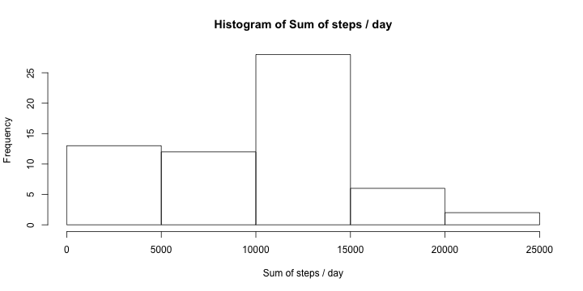

```r
hist(stepsPerDay$sum, main = "Histogram of Sum of steps / day", xlab = "Sum of steps / day")
```

3 – Calculate and report the mean and median of the total number of steps taken per day

```r
mean(stepsPerDay$sum, na.rm = TRUE)
```

```
## [1] 9354.23
```

```r
median(stepsPerDay$sum, na.rm = TRUE)
```

```
## [1] 10395
```

## What is the average daily activity pattern?

1 – Make a time series plot (i.e. type = “l”) of the 5-minute interval (x-axis) and the average number of steps taken, averaged across all days (y-axis)

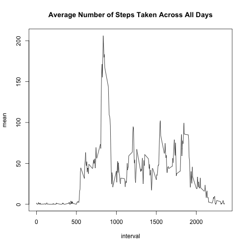

```r
stepsPerInterval <- aggregate(activity$steps, by = list(activity$interval), FUN = mean, na.rm = TRUE)
colnames(stepsPerInterval) <- c("interval", "mean")
plot(stepsPerInterval, type = "l", main = "Average Number of Steps Taken Across All Days")
```

2 – Which 5-minute interval, on average across all the days in the dataset, contains the maximum number of steps?

```r
stepsPerInterval[stepsPerInterval$mean == max(stepsPerInterval$mean),]$interval
```

```
## [1] 835
```

## Inputing missing values

1 – Calculate and report the total number of missing values in the dataset

```r
nrow(activity[is.na(activity$steps), ])
```

```
## [1] 2304
```

2 – Devise a strategy for filling in all of the missing values in the dataset. The strategy does not need to be sophisticated. For example, you could use the mean/median for that day, or the mean for that 5-minute interval, etc.

```r
# stepsPerInterval contains the mean steps for each interval.
# Create a new dataset with the original values plus a column
# with the mean for each interval.
activity2 <- merge(activity, stepsPerInterval, by = "interval")
```

3 – Create a new dataset that is equal to the original dataset but with the missing data filled in.

```r
# For each step value, use the original value, if there is one
# Or replace na's with the mean value
activity2$steps <- ifelse(is.na(activity2$steps), activity2$mean, activity2$steps)

# Remove the added columns so the new dataset looks like the old.
activity2 <- activity2[, colnames(activity)]
```

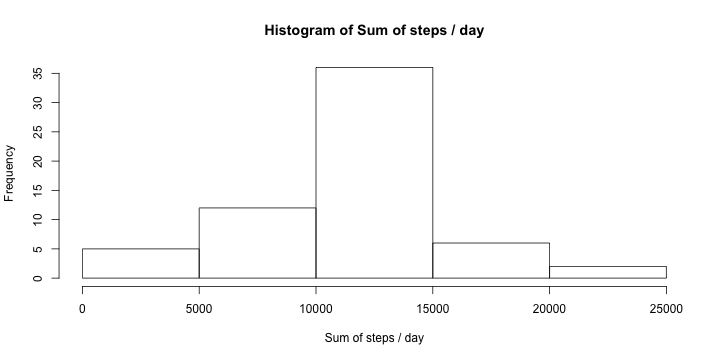

```r
stepsPerDay2 <- aggregate(activity2$steps, by = list(activity2$date), FUN = sum, na.rm = TRUE)
colnames(stepsPerDay2) <- c("date", "sum")

hist(stepsPerDay2$sum, main = "Histogram of Sum of steps / day", xlab = "Sum of steps / day")
```

What is the impact of imputing missing data on the estimates of the total daily number of steps?

> New histogram has become more bellshaped

## Are there differences in activity patterns between weekdays and weekends?

1 – Create a new factor variable in the dataset with two levels – “weekday” and “weekend” indicating whether a given date is a weekday or weekend day.

```r
activity2$weekdaytype <-  as.factor(ifelse(weekdays(activity2$date) %in% c("Saturday", "Sunday"), "Weekend", "Weekday"))
```

2 – Make a panel plot containing a time series plot (i.e. type = “l”) of the 5-minute interval (x-axis) and the average number of steps taken, averaged across all weekday days or weekend days (y-axis).

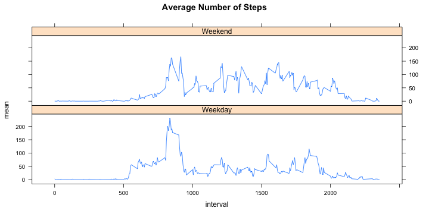

```r
stepsPerInterval2 <- aggregate(activity2$steps, by = list(activity2$interval, activity2$weekdaytype), FUN = mean, na.rm = TRUE)
colnames(stepsPerInterval2) <- c("interval", "weekdaytype", "mean")

library(lattice)
xyplot(mean ~ interval | weekdaytype, stepsPerInterval2, type = "l", layout = c(1,2), main = "Average Number of Steps")
```